# Class 1 methods 3

Caroline Hommel

9/15/2021

# 3) Brushing up on the General Linear Model

We’ll do a light start and get you back in the game of thinking about formulae and how to build your linear models  
Finally, we’ll have a few exercises, finishing off today’s practical exercises

## A list of formulae

```r
formula <- y ~ x ## y as a function of x
y ~ 1 ## model the intercept for "y"
```

```
## y ~ 1
```

```r
y ~ x ## model the main effect of x and the intercept for y
```

```
## y ~ x
```

```r
y ~ x + 1 ## the same as above (+ 1 is implicit)
```

```
## y ~ x + 1
```

```r
y ~ x + 0 ## model the main effect of x and no intercept
```

```
## y ~ x + 0
```

```r
y ~ x - 1 ## the same as above
```

```
## y ~ x - 1
```

```r
y ~ 0 ## doesn't model anything (for completeness)
```

```
## y ~ 0
```

```r
y ~ x + z ## model the main effects x and z (and an intercept)
```

```
## y ~ x + z
```

```r
y ~ x:z ## model interaction of x and z
```

```
## y ~ x:z
```

```r
y ~ x * z ## model the main effects x and z and their interaction
```

```
## y ~ x * z
```

```r
y ~ x + z + x:z ## the same as above
```

```
## y ~ x + z + x:z
```

## Dataset mtcars

Let’s look at the “mtcars” data:

[, 1] mpg Miles/(US) gallon  
[, 2] cyl Number of cylinders  
[, 3] disp Displacement (cu.in.)  
[, 4] hp Gross horsepower  
[, 5] drat Rear axle ratio  
[, 6] wt Weight (lb/1000)  
[, 7] qsec 1/4 mile time  
[, 8] vs V/S  
[, 9] am Transmission (0 = automatic, 1 = manual)  
[,10] gear Number of forward gears  
[,11] carb Number of carburetors

## Miles per gallon and weight

We can do a scatter plot, and it looks like there is some relation between fuel usage and the weight of cars. Let’s investigate this further

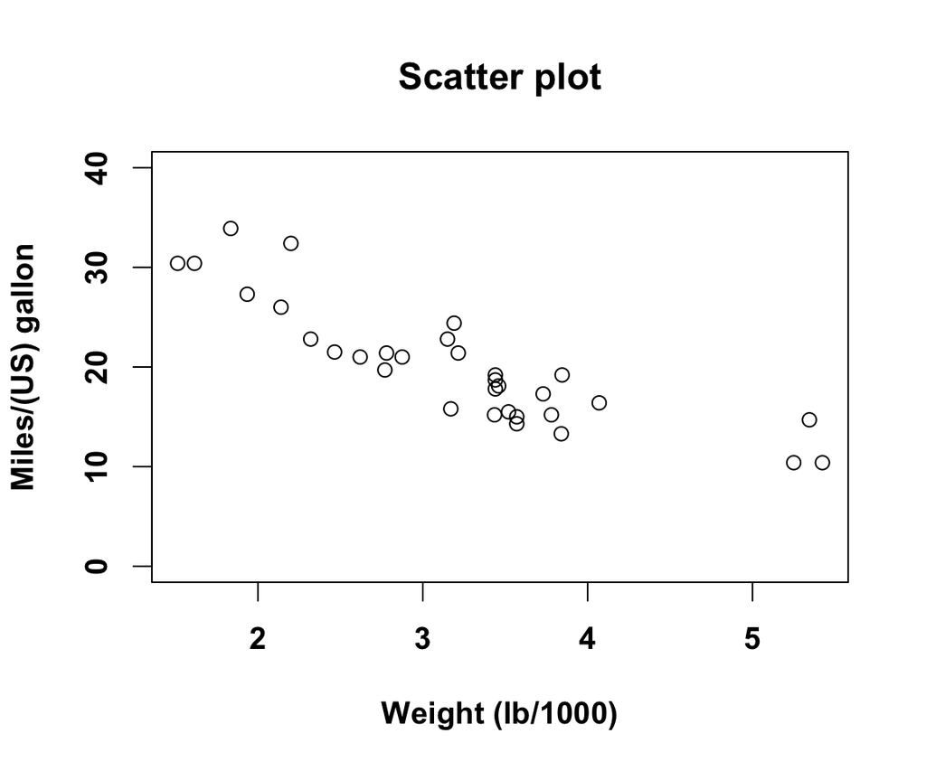

```r
par(font.lab=2, font.axis=2, cex=1.2)
plot(mpg ~ wt, data=mtcars, xlab='Weight (lb/1000)', ylab='Miles/(US) gallon',
     main='Scatter plot', ylim=c(0, 40))
```

# Exercises and objectives

The objectives of today’s exercises are:  
1) To remind you of the (general) linear model, and how we can use it to make models in R  
2) To make some informal model comparisons  
3) To estimate models based on binomially distributed data

If you would like to read more about a given function, just prepend the function with a question mark, e.g.

```r
?lm
```

REMEMBER: In your report, make sure to include code that can reproduce the answers requested in the exercises below